# NagasayanaRaoKuchibhotla_AIML_ML_Project_full_code_notebook copy

### Model Building

```python
def model_performance_classification_sklearn(model, predictors, target, average='binary', include_proba=False):
    """
    Computes classification performance metrics using scikit-learn.

    Parameters:
    -----------
    model : Trained classifier
        The fitted classification model (must implement .predict and optionally .predict_proba).
    predictors : array-like
        Feature matrix for evaluation.
    target : array-like
        True class labels.
    average : str
        Averaging method for multi-class metrics ('binary', 'macro', 'weighted', etc.).
    include_proba : bool
        Whether to include ROC AUC and Log Loss in the evaluation (requires predict_proba support).

    Returns:
    --------
    pd.DataFrame with metrics
    """

    pred = model.predict(predictors)

    # Standard classification metrics
    acc = accuracy_score(target, pred)
    recall = recall_score(target, pred, average=average)
    precision = precision_score(target, pred, average=average)
    f1 = f1_score(target, pred, average=average)
    ROC_AUC = ROC_AUC_score = None

    results = {
        "Accuracy": acc,
        "Precision": precision,
        "Recall": recall,
        "F1": f1
    }

    # Optional: Include probabilistic metrics
    if include_proba and hasattr(model, "predict_proba"):
        proba = model.predict_proba(predictors)
        if len(model.classes_) == 2:
            roc_auc = roc_auc_score(target, proba[:, 1])
        else:
            roc_auc = roc_auc_score(target, proba, multi_class='ovr', average=average)
        ll = log_loss(target, proba)
        results["ROC AUC"] = roc_auc
        results["Log Loss"] = ll

    return pd.DataFrame(results, index=[0])
```

```python
def confusion_matrix_sklearn(model, predictors, target):
    """
    To plot the confusion_matrix with percentages

    model: classifier
    predictors: independent variables
    target: dependent variable
    """
    y_pred = model.predict(predictors)
    cm = confusion_matrix(target, y_pred)
    labels = np.asarray(
        [
            ["{0:0.0f}".format(item) + "\n{0:.2%}".format(item / cm.flatten().sum())]
            for item in cm.flatten()
        ]
    ).reshape(2, 2)

    plt.figure(figsize=(6, 4))
    sns.heatmap(cm, annot=labels, fmt="")
    plt.ylabel("True label")
    plt.xlabel("Predicted label")
```

```
Model Performance (Decision Tree - Gini):
   Accuracy  Precision  Recall   F1  ROC AUC      Log Loss
0       1.0        1.0     1.0  1.0      1.0  2.220446e-16
Confusion Matrix:
```

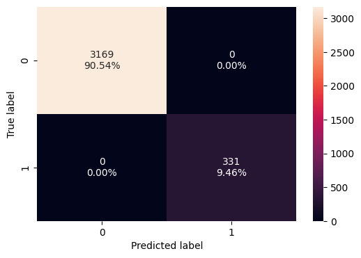

```python
# Create a Decision Tree Classifier with Gini impurity criterion
# This is a common choice for classification tasks, especially when interpretability is important.
dt_gini = DecisionTreeClassifier(
    criterion='gini',
    max_depth=None,
    min_samples_split=2,
    random_state=42
)

# Train the model
dt_gini.fit(X_train, y_train)


# Run model performance metrics
model_metrics_Train = model_performance_classification_sklearn(
    dt_gini, X_train, y_train, average='binary', include_proba=True
)

print("Model Performance (Decision Tree - Gini):")
print(model_metrics_Train)

# Plot confusion matrix
print("Confusion Matrix:")
confusion_matrix_sklearn(dt_gini, X_train, y_train)
```

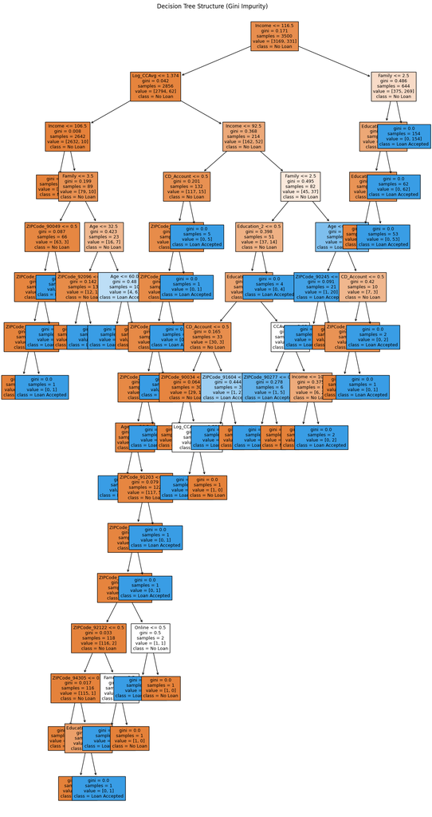

```
|--- Income <= 116.50
|   |--- Log_CCAvg <= 1.37
|   |   |--- Income <= 106.50
|   |   |   |--- class: 0
|   |   |--- Income >  106.50
|   |   |   |--- Family <= 3.50
|   |   |   |   |--- ZIPCode_90049 <= 0.50
|   |   |   |   |   |--- ZIPCode_93106 <= 0.50
|   |   |   |   |   |   |--- ZIPCode_92007 <= 0.50
|   |   |   |   |   |   |   |--- class: 0
|   |   |   |   |   |   |--- ZIPCode_92007 >  0.50
|   |   |   |   |   |   |   |--- class: 1
|   |   |   |   |   |--- ZIPCode_93106 >  0.50
|   |   |   |   |   |   |--- class: 1
|   |   |   |   |--- ZIPCode_90049 >  0.50
|   |   |   |   |   |--- class: 1
|   |   |   |--- Family >  3.50
|   |   |   |   |--- Age <= 32.50
|   |   |   |   |   |--- ZIPCode_92096 <= 0.50
|   |   |   |   |   |   |--- class: 0
|   |   |   |   |   |--- ZIPCode_92096 >  0.50
|   |   |   |   |   |   |--- class: 1
|   |   |   |   |--- Age >  32.50
|   |   |   |   |   |--- Age <= 60.00
|   |   |   |   |   |   |--- class: 1
|   |   |   |   |   |--- Age >  60.00
|   |   |   |   |   |   |--- class: 0
|   |--- Log_CCAvg >  1.37
|   |   |--- Income <= 92.50
|   |   |   |--- CD_Account <= 0.50
|   |   |   |   |--- ZIPCode_94105 <= 0.50
|   |   |   |   |   |--- ZIPCode_94122 <= 0.50
|   |   |   |   |   |   |--- ZIPCode_94709 <= 0.50
|   |   |   |   |   |   |   |--- ZIPCode_92521 <= 0.50
|   |   |   |   |   |   |   |   |--- Age <= 26.50
|   |   |   |   |   |   |   |   |   |--- class: 1
|   |   |   |   |   |   |   |   |--- Age >  26.50
|   |   |   |   |   |   |   |   |   |--- ZIPCode_91203 <= 0.50
|   |   |   |   |   |   |   |   |   |   |--- ZIPCode_92220 <= 0.50
|   |   |   |   |   |   |   |   |   |   |   |--- truncated branch of depth 5
```

[output cut: 54 more lines]

```
|   |   |   |   |   |   |--- ZIPCode_94606 >  0.50
|   |   |   |   |   |   |   |--- class: 1
|   |   |   |   |   |--- CD_Account >  0.50
|   |   |   |   |   |   |--- class: 1
|--- Income >  116.50
|   |--- Family <= 2.50
|   |   |--- Education_3 <= 0.50
|   |   |   |--- Education_2 <= 0.50
|   |   |   |   |--- class: 0
|   |   |   |--- Education_2 >  0.50
|   |   |   |   |--- class: 1
|   |   |--- Education_3 >  0.50
|   |   |   |--- class: 1
|   |--- Family >  2.50
|   |   |--- class: 1
```

```python
#show the decision tree
from sklearn.tree import plot_tree
plt.figure(figsize=(15, 30))
plot_tree(dt_gini, filled=True, feature_names=X_train.columns, fontsize=9,node_ids=False,class_names=['No Loan', 'Loan Accepted'])

plt.title("Decision Tree Structure (Gini Impurity)")
plt.show()

# Text report showing the rules of a decision tree -

from sklearn import tree

print(tree.export_text(dt_gini, feature_names=list(X_train.columns)))
```

```
Feature Importances (Decision Tree - Gini) for :
           Feature  Importance
1           Income    0.302821
2           Family    0.248530
480    Education_2    0.165238
481    Education_3    0.144207
9        Log_CCAvg    0.039465
..             ...         ...
165  ZIPCode_92104    0.000000
164  ZIPCode_92103    0.000000
163  ZIPCode_92101    0.000000
161  ZIPCode_92093    0.000000
241  ZIPCode_92886    0.000000

[482 rows x 2 columns]
```

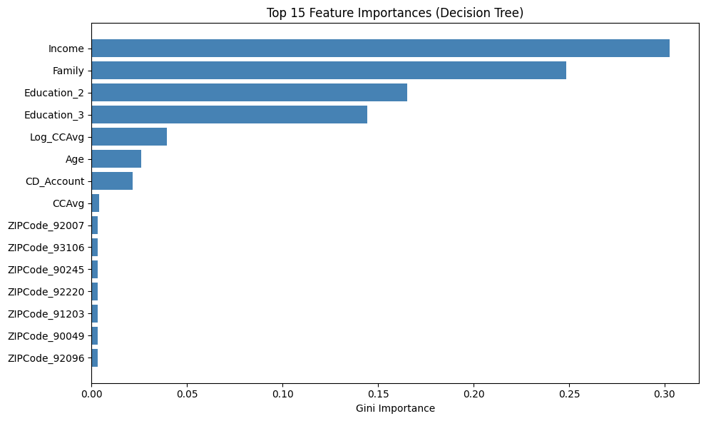

```python
# Get feature importances from trained tree
importances = dt_gini.feature_importances_

# Match importance values to feature names
feature_importance_df = pd.DataFrame({
    'Feature': X_train.columns,
    'Importance': importances
})

# Sort descending by importance
feature_importance_df = feature_importance_df.sort_values(by='Importance', ascending=False)

print("\nFeature Importances (Decision Tree - Gini) for :")
print(feature_importance_df)

# Display top 15 most important features since the decision tree has many features
top_n = 15
plt.figure(figsize=(10, 6))
plt.barh(
    y=feature_importance_df['Feature'].head(top_n)[::-1],
    width=feature_importance_df['Importance'].head(top_n)[::-1],
    color='steelblue'
)
plt.xlabel('Gini Importance')
plt.title(f'Top {top_n} Feature Importances (Decision Tree)')
plt.tight_layout()
plt.show()
```

```python
# Performance metrics on test data
model_metrics_testing = model_performance_classification_sklearn(
    dt_gini, X_test, y_test, average='binary', include_proba=True
)
model_metrics_testing
```

|  | Accuracy | Precision | Recall | F1 | ROC AUC | Log Loss |
| --- | --- | --- | --- | --- | --- | --- |
| 0 | 0.984 | 0.956204 | 0.879195 | 0.916084 | 0.937377 | 0.576698 |

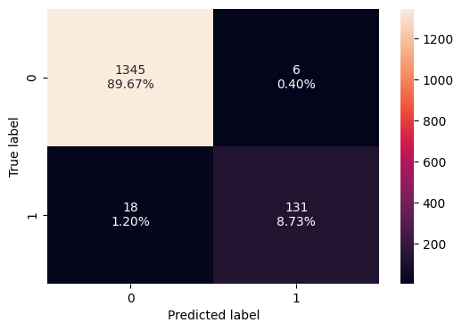

```python
# Visualize the confusion matrix for test set
confusion_matrix_sklearn(dt_gini, X_test, y_test)
```

### Decision Tree Insights

- **Income** is the most decisive variable — it’s the root split.
- Other key splitters include **Family size**, **Education**, **ZIP Code**, and **Age**.
- The tree favors **approved loans** (blue nodes) more frequently in deeper branches.
- Some paths rely heavily on indicators like **CCAvg**, **CD Account** or **Online**.
- **Overall:** the tree has learned a structured profile for likely approvals.

### Quick Observations from test data

- **High accuracy** and **excellent precision** — model avoids false positives very effectively.
- **Strong recall** at ~88% — it's catching most approved loans, though still missing a few.
- **ROC AUC of ~0.94** — indicates strong overall ranking ability.
- **Log Loss** is decent — shows confident predictions with low uncertainty.

Finally, this sets the stage for model improvement. We can review and move ahead reviewing the performance before and after pruning.

## Model Performance Improvement

### Pre-Pruning

```python
# Define the parameters of the tree to iterate over
max_depth_values = np.arange(2, 7, 2)
max_leaf_nodes_values = [50, 75, 150, 250]
min_samples_split_values = [10, 30, 50, 70]

# Initialize variables to store the best model and its performance
best_estimator = None
best_score_diff = float('inf')
best_test_score = 0.0

# Iterate over all combinations of the specified parameter values
for max_depth in max_depth_values:
    for max_leaf_nodes in max_leaf_nodes_values:
        for min_samples_split in min_samples_split_values:

            # Initialize the tree with the current set of parameters
            estimator = DecisionTreeClassifier(
                max_depth=max_depth,
                max_leaf_nodes=max_leaf_nodes,
                min_samples_split=min_samples_split,
                class_weight='balanced',
                random_state=42
            )

            # Fit the model to the training data
            estimator.fit(X_train, y_train)

            # Make predictions on the training and test sets
            y_train_pred = estimator.predict(X_train)
            y_test_pred = estimator.predict(X_test)

            # Calculate recall scores for training and test sets
            train_recall_score = recall_score(y_train, y_train_pred)
            test_recall_score = recall_score(y_test, y_test_pred)

            # Calculate the absolute difference between training and test recall scores
            score_diff = abs(train_recall_score - test_recall_score)

            # Update the best estimator and best score if the current one has a smaller score difference
            if (score_diff < best_score_diff) & (test_recall_score > best_test_score):
                best_score_diff = score_diff
                best_test_score = test_recall_score
                best_estimator = estimator

# Print the best parameters
print("Best parameters found:")
print(f"Max depth: {best_estimator.max_depth}")
print(f"Max leaf nodes: {best_estimator.max_leaf_nodes}")
print(f"Min samples split: {best_estimator.min_samples_split}")
print(f"Best test recall score: {best_test_score}")
```

```
Best parameters found:
Max depth: 2
Max leaf nodes: 50
Min samples split: 10
Best test recall score: 1.0
```

```
   Accuracy  Precision  Recall        F1  ROC AUC  Log Loss
0  0.790286   0.310798     1.0  0.474212  0.93992  0.300876
```

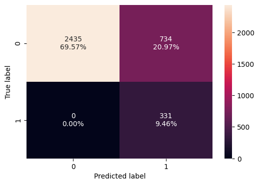

```python
# Evaluate on test data
performance_df = model_performance_classification_sklearn(
    best_estimator, X_train, y_train, include_proba=True
)
print(performance_df)

# Confusion matrix heatmap
confusion_matrix_sklearn(best_estimator, X_train, y_train)
```

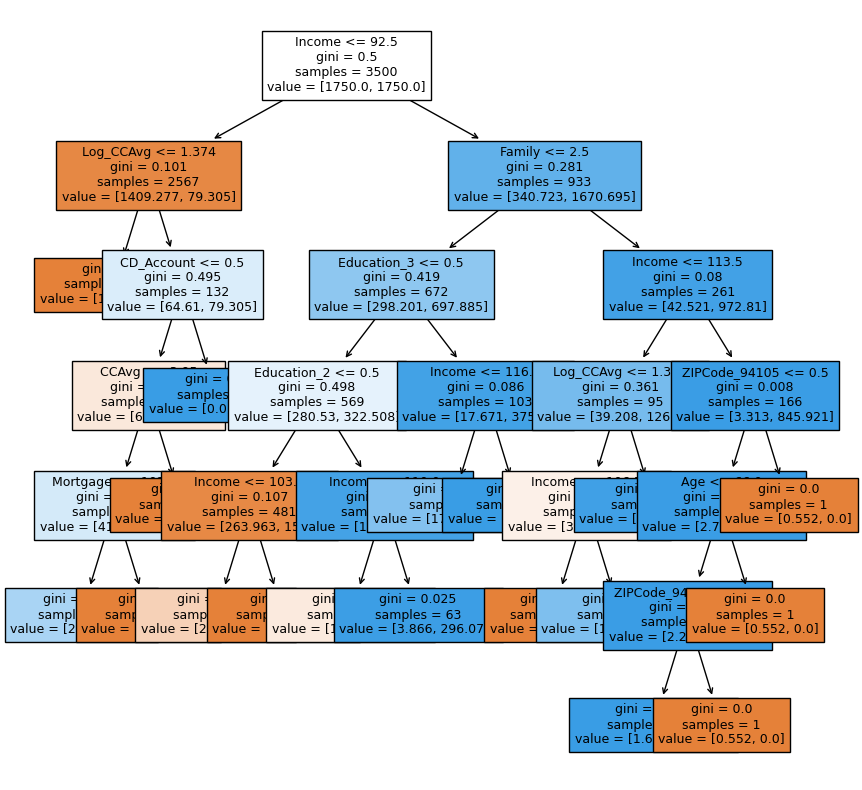

```python
plt.figure(figsize=(10, 10))
out = tree.plot_tree(
    estimator,
    feature_names=list(X_train.columns),
    filled=True,
    fontsize=9,
    node_ids=False,
    class_names=None,
)
# below code will add arrows to the decision tree split if they are missing
for o in out:
    arrow = o.arrow_patch
    if arrow is not None:
        arrow.set_edgecolor("black")
        arrow.set_linewidth(1)
plt.show()
```

```python
print(tree.export_text(estimator, feature_names=feature_names, show_weights=True))
```

```
|--- Income <= 92.50
|   |--- Log_CCAvg <= 1.37
|   |   |--- weights: [1344.67, 0.00] class: 0
|   |--- Log_CCAvg >  1.37
|   |   |--- CD_Account <= 0.50
|   |   |   |--- CCAvg <= 3.95
|   |   |   |   |--- Mortgage <= 102.50
|   |   |   |   |   |--- weights: [29.82, 52.87] class: 1
|   |   |   |   |--- Mortgage >  102.50
|   |   |   |   |   |--- weights: [11.60, 0.00] class: 0
|   |   |   |--- CCAvg >  3.95
|   |   |   |   |--- weights: [23.19, 0.00] class: 0
|   |   |--- CD_Account >  0.50
|   |   |   |--- weights: [0.00, 26.44] class: 1
|--- Income >  92.50
|   |--- Family <= 2.50
|   |   |--- Education_3 <= 0.50
|   |   |   |--- Education_2 <= 0.50
|   |   |   |   |--- Income <= 103.50
|   |   |   |   |   |--- weights: [24.85, 15.86] class: 0
|   |   |   |   |--- Income >  103.50
|   |   |   |   |   |--- weights: [239.11, 0.00] class: 0
|   |   |   |--- Education_2 >  0.50
|   |   |   |   |--- Income <= 110.00
|   |   |   |   |   |--- weights: [12.70, 10.57] class: 0
|   |   |   |   |--- Income >  110.00
|   |   |   |   |   |--- weights: [3.87, 296.07] class: 1
|   |   |--- Education_3 >  0.50
|   |   |   |--- Income <= 116.50
|   |   |   |   |--- weights: [17.67, 47.58] class: 1
|   |   |   |--- Income >  116.50
|   |   |   |   |--- weights: [0.00, 327.79] class: 1
|   |--- Family >  2.50
|   |   |--- Income <= 113.50
|   |   |   |--- Log_CCAvg <= 1.33
|   |   |   |   |--- Income <= 106.50
|   |   |   |   |   |--- weights: [24.85, 0.00] class: 0
|   |   |   |   |--- Income >  106.50
|   |   |   |   |   |--- weights: [11.04, 31.72] class: 1
|   |   |   |--- Log_CCAvg >  1.33
|   |   |   |   |--- weights: [3.31, 95.17] class: 1
|   |   |--- Income >  113.50
|   |   |   |--- ZIPCode_94105 <= 0.50
|   |   |   |   |--- Age <= 66.00
|   |   |   |   |   |--- ZIPCode_94608 <= 0.50
|   |   |   |   |   |   |--- weights: [1.66, 845.92] class: 1
|   |   |   |   |   |--- ZIPCode_94608 >  0.50
|   |   |   |   |   |   |--- weights: [0.55, 0.00] class: 0
|   |   |   |   |--- Age >  66.00
|   |   |   |   |   |--- weights: [0.55, 0.00] class: 0
|   |   |   |--- ZIPCode_94105 >  0.50
|   |   |   |   |--- weights: [0.55, 0.00] class: 0
```

```python
# importance of features in the tree building ( The importance of a feature is computed as the
# (normalized) total reduction of the criterion brought by that feature. It is also known as the Gini importance )

print(
    pd.DataFrame(
        estimator.feature_importances_, columns=["Imp"], index=X_train.columns
    ).sort_values(by="Imp", ascending=False)
)
```

```
                    Imp
Income         0.676489
Education_2    0.147212
Log_CCAvg      0.060917
Education_3    0.051832
Family         0.041120
...                 ...
ZIPCode_92101  0.000000
ZIPCode_92096  0.000000
ZIPCode_92093  0.000000
ZIPCode_92084  0.000000
ZIPCode_92886  0.000000

[482 rows x 1 columns]
```

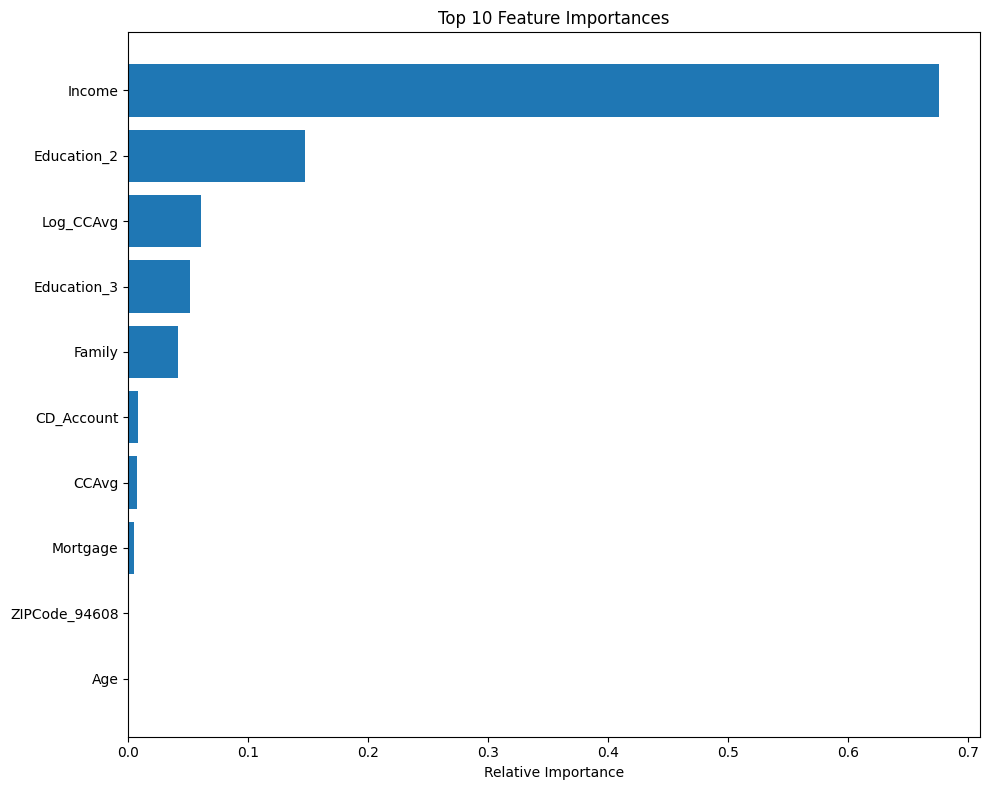

```python
importances = estimator.feature_importances_
indices = np.argsort(importances)[-10:]  # Select top 20 by slicing the last 20 indices

# Optional: Get feature names if not already defined
feature_names = X_train.columns.tolist()

plt.figure(figsize=(10, 8))
plt.title("Top 10 Feature Importances")
plt.barh(range(10), importances[indices],  align="center")
plt.yticks(range(10), [feature_names[i] for i in indices])
plt.xlabel("Relative Importance")
plt.tight_layout()
plt.show()
```

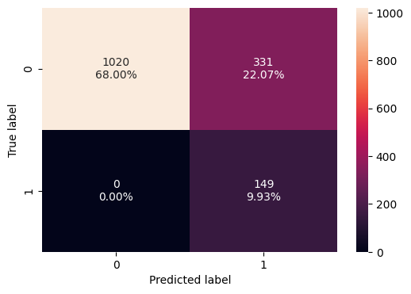

```python
confusion_matrix_sklearn(best_estimator, X_test, y_test)
```

```python
decision_tree_tune_perf_test = model_performance_classification_sklearn(best_estimator, X_test, y_test, include_proba=True) ## Complete the code to check performance on test data
print("Performance of the tuned Decision Tree on Test Data:")
print(decision_tree_tune_perf_test)
print("")
print("Performance of the tuned Decision Tree on Train Data:")
print(performance_df)
```

```
Performance of the tuned Decision Tree on Test Data:
   Accuracy  Precision  Recall        F1  ROC AUC  Log Loss
0  0.779333   0.310417     1.0  0.473768  0.92423  0.322875

Performance of the tuned Decision Tree on Train Data:
   Accuracy  Precision  Recall        F1  ROC AUC  Log Loss
0  0.790286   0.310798     1.0  0.474212  0.93992  0.300876
```